# Coffee Sales

Abishek Chaudhari

```r
#library(tidyverse)
#library(dplyr)
data = read.csv("D:/My_DS_Internship/Coffee_sales/index.csv")
names(data)
```

```
[1] "date"        "datetime"    "cash_type"   "card"
[5] "money"       "coffee_name"
```

Data Preprocessing

```r
#Check if any column has null data
colSums(is.na(data))
```

[output not shown]

Exploratory Data Analysis 1. Outlier Detection

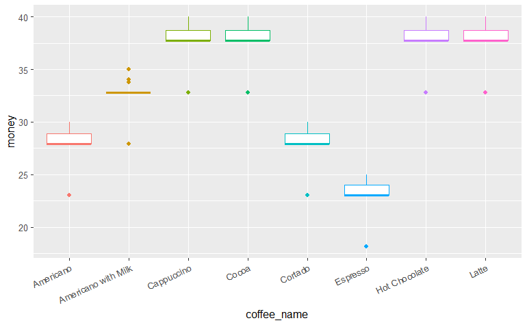

```r
ggplot(data,aes(coffee_name,money, color = coffee_name))+
  geom_boxplot()+
  theme(axis.text.x = element_text(angle = 25, hjust = 1),
          legend.position = 'none')
```

```r
NA
```

In the above plot,none of the outliers are wildly out of sync with general coffee pricing. We’re not seeing a coffee priced at 2 or 100. They are generally within a reasonable deviation.

2. Distribution of Sales over different hour of day

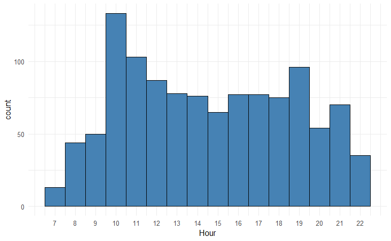

```r
ggplot(data, aes(Hour)) +
  geom_histogram(binwidth = 1,color = "black" ,fill = 'steelblue') +
  theme_minimal()+
  scale_x_continuous(breaks = seq(min(data$Hour, na.rm=TRUE),
                                  max(data$Hour, na.rm=TRUE), by = 1))
```

```r
NA
NA
NA
```

We see that the sales of coffee is higher at two times of the day around 10 AM and 19 PM . Inventory of coffee can be managed as per this distribution.

3.Total Revenue Generated by Different Coffee Types

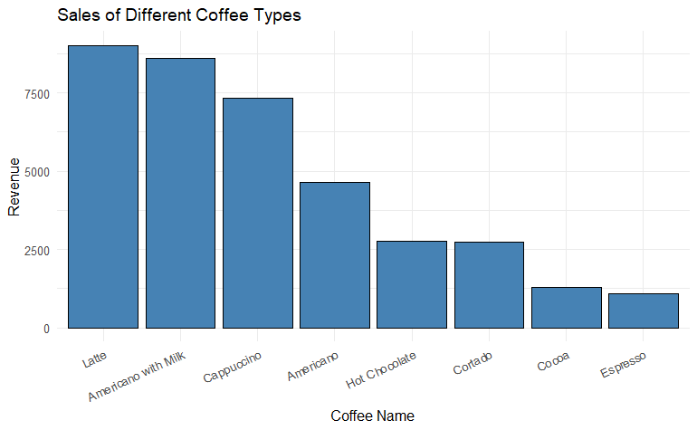

```r
#Sales by Coffee_Name
#Plotting each coffee type and their total generated revenue over the full period
data %>% group_by(coffee_name)%>%
  summarize(total_sales = sum(money),count = n(),.groups = 'drop') %>%
  ggplot(aes(x = reorder(coffee_name,-total_sales),y = total_sales)) +
  geom_bar(stat = 'identity',color = 'black',fill = "steelblue") +
  labs(title = "Sales of Different Coffee Types",
       x = "Coffee Name",
       y = "Revenue")+
  theme_minimal() +
  theme(axis.text.x = element_text(angle = 25, hjust = 1),
          legend.position = 'none')
```

From the chart, it is clear that Latte, Americano with Milk and Cappuccino are the three most popular and highly sold coffee while Espresso is the least.

4.Coffee Sales on different Day Hours

To visualize the demand of different coffee on different time of the day, plots are generated and kept on the same row for comparison.Four coffee types have mean sales in a day greater than 10,these four are plotted below:

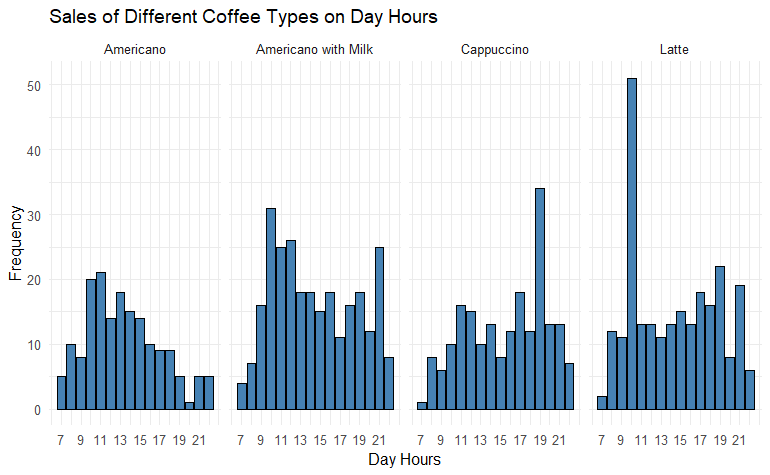

```r
#Coffee sales trend
intermediate_data <- data %>%
  group_by(Hour,coffee_name)%>%
  summarize(total_count = n(),.groups = 'drop')%>%
  arrange(coffee_name,Hour)
#Sales Trend in hours of a day in top four coffee type
mean <- intermediate_data %>% group_by(coffee_name)%>%
  summarize(mean = mean(total_count))%>% arrange(desc(mean))
intermediate_data %>%
  arrange(coffee_name)%>%
  filter(coffee_name %in% mean$coffee_name[1:4])%>%
  ggplot(aes(x = Hour,y = total_count)) +
  geom_bar(stat = 'identity',color = 'black' ,fill = 'steelblue')+
  facet_wrap(.~ coffee_name, ncol = 4)+
  labs(title = "Sales of Different Coffee Types on Day Hours",
       x = "Day Hours",
       y = "Frequency")+
  theme_minimal() +
  scale_x_continuous(breaks = seq(min(data$Hour, na.rm=TRUE),
                                  max(data$Hour, na.rm=TRUE), by = 2))
```

Below are the plots of coffee type with mean sales below 10 in a day:

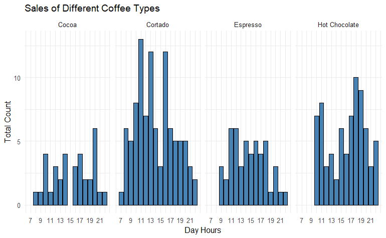

```r
#Sales Trend in hours of a day in bottom four coffee type

intermediate_data %>%
  arrange(coffee_name)%>%
  filter(coffee_name %in% mean$coffee_name[5:8])%>%
  ggplot(aes(x = Hour,y = total_count)) +
  geom_bar(stat = 'identity', color = 'black',fill = 'steelblue')+
  facet_wrap(.~ coffee_name, ncol = 4)+
  labs(title = "Sales of Different Coffee Types",
       x = "Day Hours",
       y = "Total Count")+
  theme_minimal() +
  scale_x_continuous(breaks = seq(min(data$Hour, na.rm=TRUE),
                                  max(data$Hour, na.rm=TRUE), by = 2))
```

5. Coffee Sales Over Days In a Week

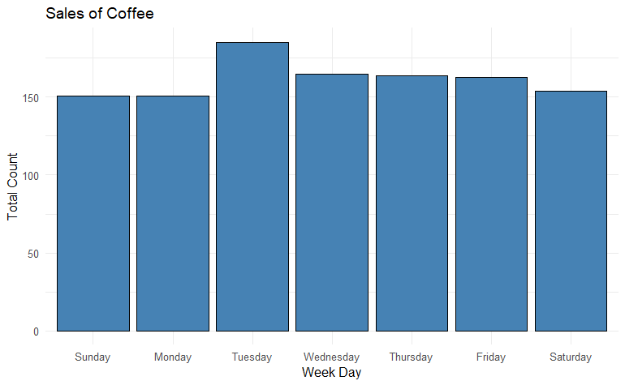

```r
#Coffee Sales report per week days in 4 months
day_data <- data %>%
  mutate(day = format(data$date,"%A"))%>%
  group_by(day)%>%
  summarize(total_count = n(),.groups = 'drop')
# Assuming your day column is called `day`
day_data$day <- factor(day_data$day, levels = c("Sunday", "Monday", "Tuesday",
                                    "Wednesday", "Thursday",
                                    "Friday", "Saturday"))

day_data %>%
  ggplot(aes(x = day,y = total_count)) +
  geom_bar(stat = 'identity', color = 'black',fill = 'steelblue')+
  #geom_text(aes(label = total_count), vjust = -0.5)+
  labs(title = "Sales of Coffee",
       x = "Week Day",
       y = "Total Count")+
  theme_minimal()
```

We see the highest demand for coffee on Tuesday among the seven days in a week. This information can be very beneficial for inventory planning.

6.Coffee Sales Trend Over Time

To see trend of sales of coffee each month, we plot the total orders of coffee every month in a line chart as shown below:

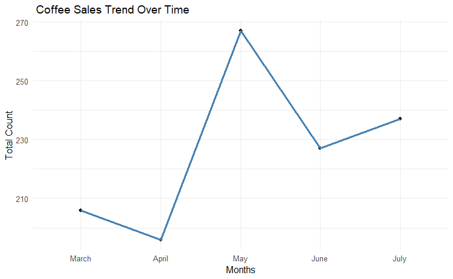

```r
#Coffee Sales Trend Over Months
data_month <- data %>% mutate(Month = format(data$date,"%B"))%>%
  group_by(Month)%>%
  summarize(total_count = n(),.groups = 'drop')
data_month$Month <- factor(data_month$Month, levels = c("March","April","May","June","July"))
data_month %>%
  ggplot(aes(x = Month,y = total_count,group = 1)) +
  geom_point()+
  geom_line(color = "steelblue", linewidth = 1.2)+
  labs(title = " Coffee Sales Trend Over Time",
       x = "Months",
       y = "Total Count")+
  theme_minimal()
```

7.Popularity of Different Coffee Types Over Time

The increasing demand may be due to some particular coffee types and not by some other types. To find this, we plot a grid of line plots for each coffee type over all 5 months

Lets see, how is the trend for each coffee type

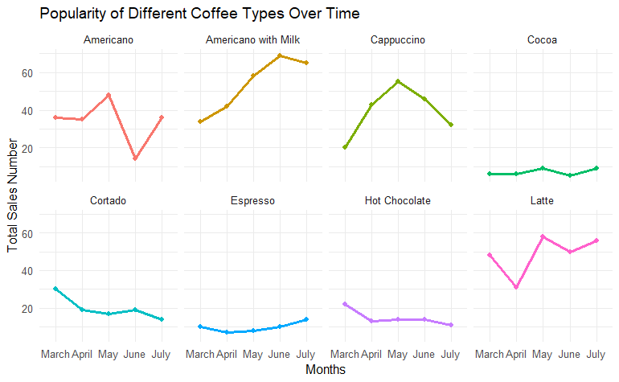

```r
#Coffee Sales Trend Over Months
data_month <- data %>% mutate(Month = format(data$date,"%B"))%>%
  group_by(Month,coffee_name)%>%
  summarize(total_count = n(),.groups = 'drop')%>%
  arrange(coffee_name)
data_month$Month <- factor(data_month$Month, levels = c("March","April","May","June","July"))

data_month %>%
  ggplot(aes(x = Month,y = total_count,color = coffee_name, group = coffee_name)) +
  geom_point()+
  geom_line(size = 1)+
  facet_wrap(.~coffee_name, ncol = 4)+
  labs(title = "Popularity of Different Coffee Types Over Time",
       x = "Months",
       y = "Total Sales Number")+
  theme_minimal()+
  theme(legend.position = 'none')
```

8. Cash and Card Transaction

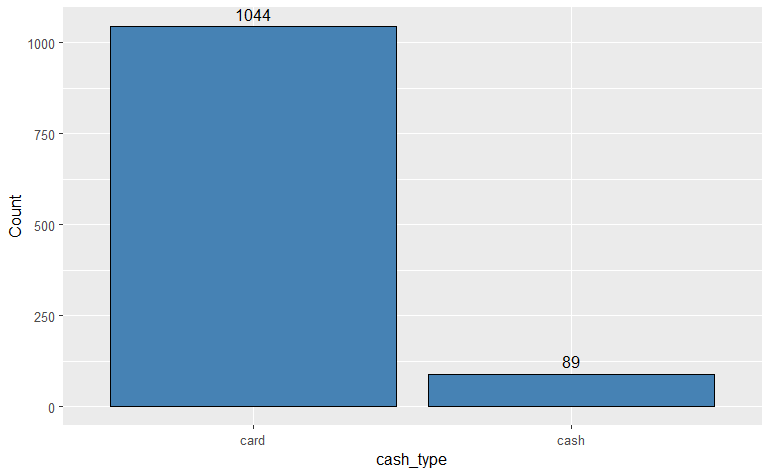

```r
data%>% group_by(cash_type)%>%
  summarize(Count = n(),.groups = "drop")%>%
  ggplot(aes(cash_type,Count))+
  geom_bar(stat="identity", fill = "steelblue", color = "black")+
  geom_text(aes(label = Count), vjust = -0.5)
```

89 out of 1133 transactions are cash type. It is about 8 % of the total transactions.

SUMMARY

1.Coffee sales peak twice a day: around 10 AM and 7 PM.

2.Highest total revenue generated by ‘Latte’, ‘Americano with Milk’, and ‘Cappuccino’.

3.’Espresso’ generated the least revenue.

5.’Hot Chocolate’ is seen to have higher demand in evening.

6.Tuesday records the highest coffee sales among all weekdays.

8.’Americano with Milk’ and ‘Latte’ show increasing demand over the months.’Cortado’ and ‘Hot Chocolate’ show a decreasing trend in demand.

9.92% of transactions are card-based; only 8% are cash.

OVERALL INSIGHTS AND RECOMMENDATION

1.Focus on popular items (‘Latte’, ‘Americano with Milk’) for promotions and stocking.

2.Expect daily demand peaks at 10 AM and 7 PM.

3.Tuesdays see the most sales — leverage this for weekday offers.

4.Certain drinks are falling in popularity (e.g., Hot Chocolate) — consider re-evaluating their presence.

5.The overwhelming majority of card payments suggests less need for cash handling resources.